# Cadence and heart rate at threshold pace

- Show All Code
- Hide All Code
- View Source

A 26-minute randomised-cadence track session

Published

November 16, 2026

# 1 Overview

The question behind this analysis is whether there is a cadence at which heart rate (HR) is lowest when running at a fixed threshold pace. If there is, it would be a practical, individual estimate of the most economical cadence.

No app or web service I could verify works out an individual, metabolically optimal cadence from ordinary Garmin or Strava uploads. That is because speed, terrain, fatigue and cadence all change together during normal runs. So the question was tested directly, with a structured session:

- **Warm-up:** 10 minutes. The watch was paused for a couple of minutes during the warm-up.
- **Test block:** 26 consecutive one-minute segments at a target pace of **3:55 min/km**, about 4.26 m/s, on a track.
- **Cadence protocol:** a metronome WAV track. Every integer cadence from **185 to 210 steps/min** was played once, for one minute, in random order. Each click is one step, counting both feet.

```r
cadence_sequence <- c(
    193, 203, 197, 188, 187, 207,
    190, 189, 205, 196, 186, 202,
    206, 210, 194, 191, 185, 209,
    199, 208, 204, 198, 195, 192,
    200, 201
)
stopifnot(setequal(cadence_sequence, 185:210),
          !anyDuplicated(cadence_sequence))
```

## 1.1 Data extraction

The segment summaries came from the Garmin FIT file, using the Python script `summarize_cadence_test.py`:

1. **Timing.** Time was measured as active timer time, rebuilt from the FIT timer start/stop events. This removes the pause during the warm-up. Lap boundaries were ignored, because Auto Lap splits the test block into several laps. The first metronome click is at timer time 600 s, set with `--tempo-start`.
2. **Windows.** For each one-minute segment, the first 20 s were dropped to let HR adjust to the transition, and the last 5 s were dropped. That leaves a 35-second window, from second 20 up to (but not including) second 55.
3. **Summaries.** For each window, the script records mean speed (converted to pace), mean HR and mean power.

This assumes the watch timer and the metronome both ran continuously through the 26-minute block.

The resulting CSV is the input to this document:

| Column | Meaning |
| --- | --- |
| `segment` | Chronological segment number (1–26) |
| `cadence_bpm` | Prescribed metronome cadence (steps/min) |
| `pace_min_per_km` | Mean pace in the 35-s window (decimal min/km) |
| `heart_rate_bpm` | Mean HR in the 35-s window |
| `power_w` | Mean running power in the 35-s window |

**Note**

`cadence_bpm` is the **prescribed** cadence, not the measured one. If measured cadence is added to the CSV, set the `cadence_column` and `cadence_label` parameters to use it instead.

# 2 Setup

```r
library(minpack.lm)
library(ggplot2)
library(dplyr)
library(tidyr)

theme_set(theme_minimal(base_size = 12))

model_colours <- c(
    current_speed  = "#1b1b1b",
    previous_speed = "#2c7fb8",
    previous_hr    = "#d95f0e"
)

model_labels <- c(
    current_speed  = "Current speed",
    previous_speed = "Current + previous speed",
    previous_hr    = "Current speed + previous HR"
)
```

## 2.1 Helper functions

```r
# AIC with small-sample correction; K includes the residual variance.
aicc <- function(model) {
    ll <- logLik(model)
    K  <- attr(ll, "df")
    n  <- nobs(model)
    if (n <= K + 1) return(Inf)
    AIC(model) + 2 * K * (K + 1) / (n - K - 1)
}

# One-row-per-model comparison table.
compare_models <- function(models, data) {
    out <- do.call(rbind, lapply(names(models), function(name) {
        m <- models[[name]]
        r <- data$y - as.numeric(predict(m, newdata = data))
        data.frame(
            model         = name,
            n             = nobs(m),
            K             = attr(logLik(m), "df"),
            RMSE_bpm      = sqrt(mean(r^2)),
            residual_lag1 = cor(head(r, -1), tail(r, -1)),
            AIC           = AIC(m),
            AICc          = aicc(m),
            converged     = isTRUE(m$convInfo$isConv)
        )
    }))
    out$delta_AICc <- out$AICc - min(out$AICc)
    out[order(out$AICc), ]
}

# Residual autocorrelations in long format, for ggplot.
acf_table <- function(residuals, model, lag_max = 6) {
    a <- acf(residuals, lag.max = lag_max, plot = FALSE)
    data.frame(
        model = model,
        lag   = as.numeric(a$lag)[-1],
        acf   = as.numeric(a$acf)[-1],
        limit = qnorm(0.975) / sqrt(length(residuals))
    )
}

# Residual time-pattern and ACF plots for a named list of models.
plot_residual_diagnostics <- function(models, data, labels = names(models)) {
    res <- bind_rows(lapply(names(models), function(name) {
        data.frame(
            model    = labels[[name]],
            segment  = data$segment,
            residual = data$y - as.numeric(predict(models[[name]], newdata = data))
        )
    }))
    res$model <- factor(res$model, levels = unname(labels[names(models)]))

    acfs <- bind_rows(lapply(split(res, res$model), function(d) {
        acf_table(d$residual, unique(d$model))
    }))
    acfs$model <- factor(acfs$model, levels = levels(res$model))

    p_time <- ggplot(res, aes(segment, residual)) +
        geom_hline(yintercept = 0, linetype = 2, colour = "grey50") +
        geom_line(colour = "grey60") +
        geom_point(size = 2) +
        geom_smooth(method = "loess", formula = y ~ x, span = 0.75,
                    se = FALSE, colour = "firebrick") +
        facet_wrap(~ model, nrow = 1) +
        labs(x = "Segment", y = "Residual HR (bpm)",
             title = "Residuals over time")

    p_acf <- ggplot(acfs, aes(lag, acf)) +
        geom_hline(yintercept = 0, colour = "grey40") +
        geom_hline(aes(yintercept = limit), linetype = 2, colour = "steelblue") +
        geom_hline(aes(yintercept = -limit), linetype = 2, colour = "steelblue") +
        geom_segment(aes(xend = lag, yend = 0), linewidth = 1.2) +
        facet_wrap(~ model, nrow = 1) +
        scale_x_continuous(breaks = 1:6) +
        coord_cartesian(ylim = c(-1, 1)) +
        labs(x = "Lag (segments)", y = "Autocorrelation",
             title = "Residual autocorrelation")

    list(time = p_time, acf = p_acf)
}
```

# 3 Data

```r
raw <- read.csv(params$data_file)

stopifnot(
    all(c("segment", "pace_min_per_km", "heart_rate_bpm",
          params$cadence_column) %in% names(raw))
)

dat <- raw |>
    arrange(segment) |>
    mutate(
        x       = segment - 1,                       # minutes into the test, starting at 0
        y       = heart_rate_bpm,
        speed   = 1000 / (60 * pace_min_per_km),     # m/s
        cadence = .data[[params$cadence_column]]
    )

stopifnot(
    nrow(dat) == 26,
    all(diff(dat$segment) == 1),
    all(complete.cases(dat[, c("x", "y", "speed", "cadence")]))
)

dat |>
    summarise(
        segments      = n(),
        mean_pace     = mean(pace_min_per_km),
        sd_speed_m_s  = sd(speed),
        mean_hr       = mean(y),
        hr_range      = paste(round(range(y), 1), collapse = "–")
    ) |>
    knitr::kable(digits = 3)
```

| segments | mean_pace | sd_speed_m_s | mean_hr | hr_range |
| --- | --- | --- | --- | --- |
| 26 | 3.895 | 0.095 | 170.254 | 159.7–175.9 |

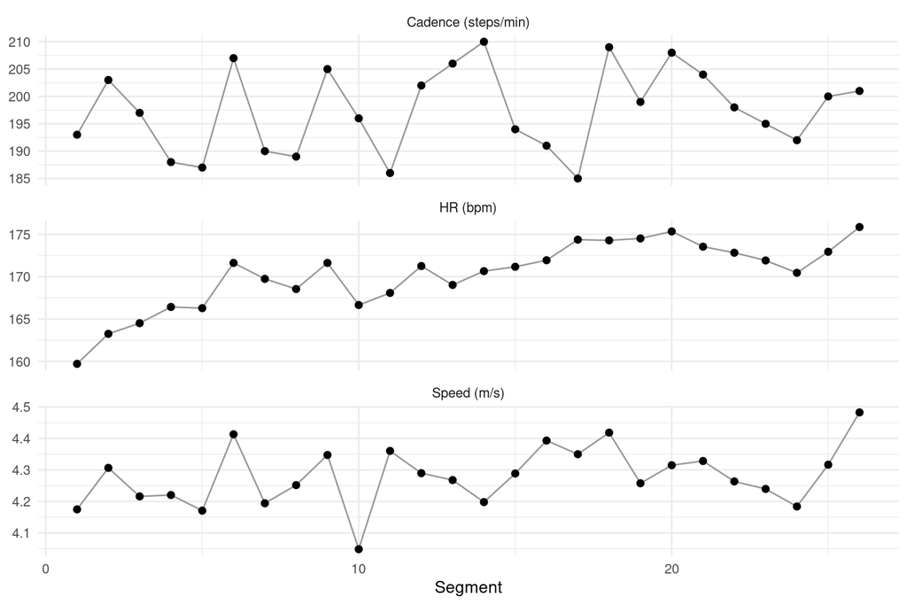

Figure 1: Segment-level HR, speed and cadence in chronological order.

```r
dat |>
    transmute(segment,
              `HR (bpm)` = y,
              `Speed (m/s)` = speed,
              `Cadence (steps/min)` = cadence) |>
    pivot_longer(-segment) |>
    ggplot(aes(segment, value)) +
    geom_line(colour = "grey60") +
    geom_point(size = 2) +
    facet_wrap(~ name, ncol = 1, scales = "free_y") +
    labs(x = "Segment", y = NULL)
```

# 4 Background HR trend over time

HR rises over the course of a sustained threshold effort, whatever the cadence. That trend has to be accounted for before cadence effects can be seen. Time is `x = segment - 1`, so the curve starts at zero.

Two time models were compared on all 26 segments:

- **Sloping asymptote.** An exponential approach to a line that keeps rising: [ HR(x) = a + bx - De^{-kx} ]
- **Horizontal asymptote.** An exponential approach to a plateau: [ HR(x) = H_{} + (H_{} - H_{})(1 - e^{-kx}) ]

The horizontal model is the sloping model with $b = 0$, using $H_{\text{final}} = a$ and $H_{\text{start}} = a - D$. In this document, `final_hr` is the **asymptotic** HR, the plateau as time goes to infinity. It is not the predicted HR at minute 26. The rate parameter is held positive, so both curves approach their asymptote.

```r
start_guess <- c(
    start_hr    = mean(dat$y[1:2]),
    final_hr    = mean(tail(dat$y, 5)),
    growth_rate = 0.3
)

fit_time <- nlsLM(
    y ~ start_hr + (final_hr - start_hr) * (1 - exp(-growth_rate * x)),
    data    = dat,
    start   = as.list(start_guess),
    lower   = c(-Inf, -Inf, 1e-8),
    control = nls.lm.control(maxiter = 1000)
)

p0 <- coef(fit_time)

fit_time_sloped <- nlsLM(
    y ~ (intercept_asymptote + slope_asymptote * x) -
        initial_deviation * exp(-rate_of_approach * x),
    data  = dat,
    start = list(
        intercept_asymptote = unname(p0["final_hr"]),
        slope_asymptote     = 0,
        initial_deviation   = unname(p0["final_hr"] - p0["start_hr"]),
        rate_of_approach    = unname(p0["growth_rate"])
    ),
    lower   = c(-Inf, -Inf, -Inf, 1e-8),
    control = nls.lm.control(maxiter = 1000)
)

time_models <- list(
    horizontal_asymptote = fit_time,
    sloping_asymptote    = fit_time_sloped
)

compare_models(time_models, dat) |> knitr::kable(digits = 3, row.names = FALSE)
```

| model | n | K | RMSE_bpm | residual_lag1 | AIC | AICc | converged | delta_AICc |
| --- | --- | --- | --- | --- | --- | --- | --- | --- |
| horizontal_asymptote | 26 | 4 | 1.806 | 0.278 | 112.523 | 114.428 | TRUE | 0.000 |
| sloping_asymptote | 26 | 5 | 1.727 | 0.264 | 112.211 | 115.211 | TRUE | 0.783 |

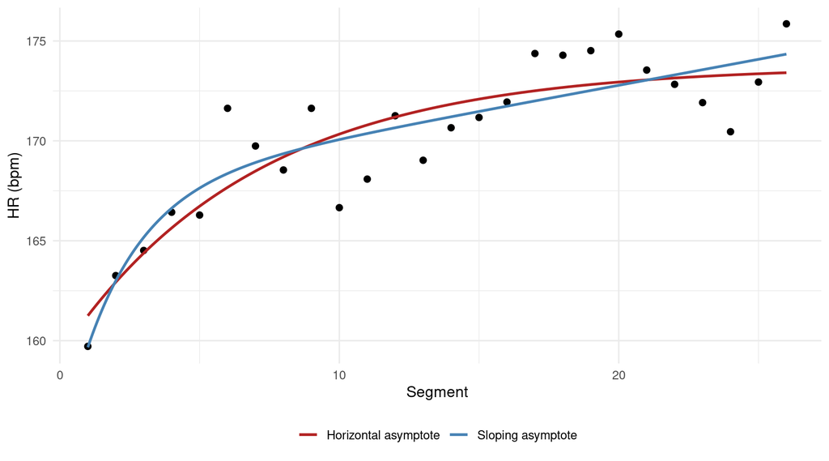

Figure 2: Observed HR with both fitted time trends.

```r
grid_time <- data.frame(x = seq(min(dat$x), max(dat$x), length.out = 300))
grid_time$segment <- grid_time$x + 1

time_curves <- bind_rows(
    data.frame(grid_time, model = "Horizontal asymptote",
               hr = predict(fit_time, newdata = grid_time)),
    data.frame(grid_time, model = "Sloping asymptote",
               hr = predict(fit_time_sloped, newdata = grid_time))
)

ggplot(dat, aes(segment, y)) +
    geom_point(size = 2) +
    geom_line(data = time_curves, aes(y = hr, colour = model), linewidth = 1) +
    scale_colour_manual(values = c("Horizontal asymptote" = "firebrick",
                                   "Sloping asymptote" = "steelblue")) +
    labs(x = "Segment", y = "HR (bpm)", colour = NULL) +
    theme(legend.position = "bottom")
```

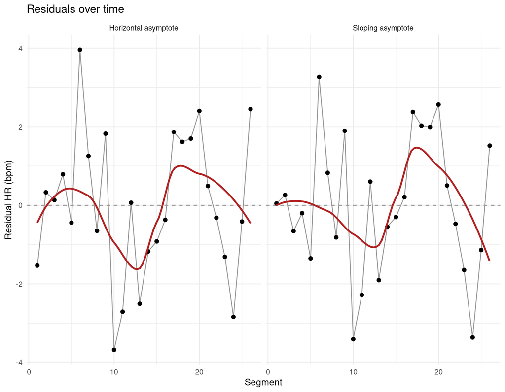

Figure 3: Residual time patterns and autocorrelation for the two time models.

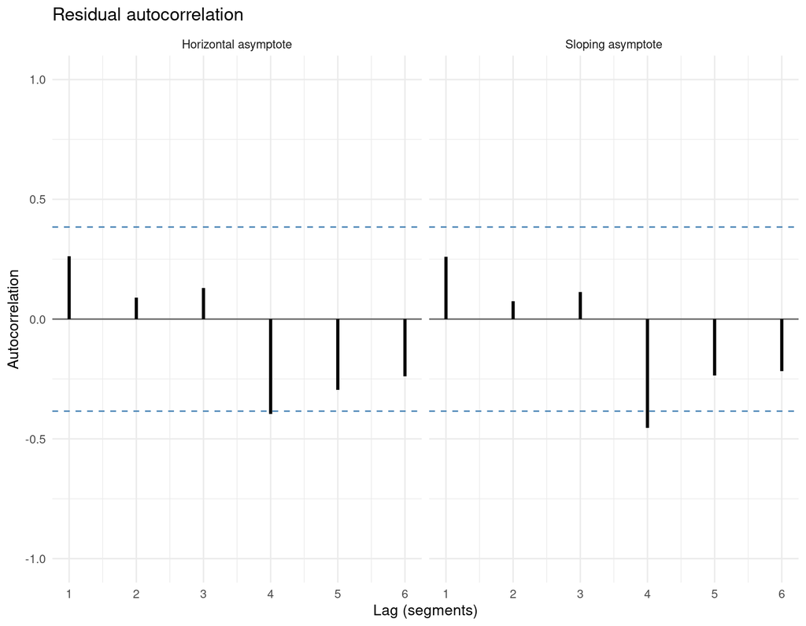

Figure 4: Residual time patterns and autocorrelation for the two time models.

```r
diag_time <- plot_residual_diagnostics(
    time_models, dat,
    labels = c(horizontal_asymptote = "Horizontal asymptote",
               sloping_asymptote    = "Sloping asymptote")
)
diag_time$time
diag_time$acf
```

The **horizontal-asymptote model was kept**. It has one fewer parameter, its parameters are better identified, and its residuals showed no time pattern that the slope term was needed to remove. Approximate (Wald) intervals:

```r
summary(fit_time)$coefficients |> knitr::kable(digits = 4)
```

|  | Estimate | Std. Error | t value | Pr(>\|t\|) |
| --- | --- | --- | --- | --- |
| start_hr | 161.2482 | 1.3818 | 116.6934 | 0.0000 |
| final_hr | 173.7504 | 1.0292 | 168.8206 | 0.0000 |
| growth_rate | 0.1442 | 0.0433 | 3.3327 | 0.0029 |

```r
confint.default(fit_time) |> knitr::kable(digits = 4)
```

|  | 2.5 % | 97.5 % |
| --- | --- | --- |
| start_hr | 158.5399 | 163.9565 |
| final_hr | 171.7332 | 175.7676 |
| growth_rate | 0.0594 | 0.2290 |

**Tip**

For `nls` fits, `confint()` uses profile likelihood. Profiling can fail when a parameter, especially the rate, is weakly constrained. `confint.default()` gives normal-approximation (Wald) intervals instead. These are approximate and can be poor for parameters bounded at zero.

# 5 Accounting for pace variation

Pace was held as steady as possible, but it still varied between segments on the track. Faster segments are expected to raise HR. Speed in m/s is used rather than pace, so a positive coefficient means *faster → higher HR*. Speed is centred on its mean.

```r
dat$v0 <- dat$speed - mean(dat$speed)
dat$hr_resid_time <- dat$y - as.numeric(predict(fit_time, newdata = dat))

speed_cor <- cor.test(dat$speed, dat$hr_resid_time)
speed_cor
```

```
    Pearson's product-moment correlation

data:  dat$speed and dat$hr_resid_time
t = 3.8068, df = 24, p-value = 0.0008572
alternative hypothesis: true correlation is not equal to 0
95 percent confidence interval:
 0.2967756 0.8087281
sample estimates:
      cor
0.6135912
```

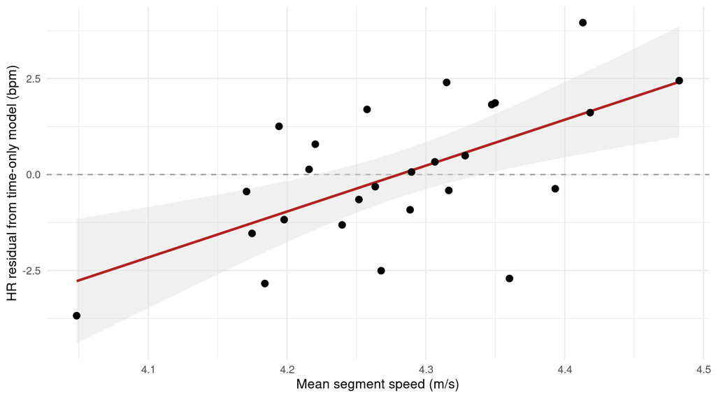

Figure 5: HR residuals from the time-only model against segment speed (exploratory).

```r
ggplot(dat, aes(speed, hr_resid_time)) +
    geom_hline(yintercept = 0, linetype = 2, colour = "grey60") +
    geom_smooth(method = "lm", formula = y ~ x, colour = "firebrick", fill = "grey85") +
    geom_point(size = 2.5) +
    labs(x = "Mean segment speed (m/s)",
         y = "HR residual from time-only model (bpm)")
```

This plot is only exploratory. The adjusted speed effect comes from fitting time and speed **together**, not from regressing the residuals on speed:

```r
fit_time_speed <- nlsLM(
    y ~ start_hr + (final_hr - start_hr) * (1 - exp(-growth_rate * x)) +
        beta_current * v0,
    data    = dat,
    start   = c(as.list(coef(fit_time)), list(beta_current = 0)),
    lower   = c(-Inf, -Inf, 1e-8, -Inf),
    control = nls.lm.control(maxiter = 1000)
)

compare_models(list(time_only = fit_time, time_speed = fit_time_speed), dat) |>
    knitr::kable(digits = 3, row.names = FALSE)
```

| model | n | K | RMSE_bpm | residual_lag1 | AIC | AICc | converged | delta_AICc |
| --- | --- | --- | --- | --- | --- | --- | --- | --- |
| time_speed | 26 | 5 | 1.366 | 0.264 | 99.992 | 102.992 | TRUE | 0.000 |
| time_only | 26 | 4 | 1.806 | 0.278 | 112.523 | 114.428 | TRUE | 11.436 |

```r
# HR difference associated with a 0.1 m/s faster segment
0.1 * c(estimate = unname(coef(fit_time_speed)["beta_current"]),
        confint.default(fit_time_speed, parm = "beta_current")[1, ])
```

```
 estimate     2.5 %    97.5 %
1.3601643 0.7051265 2.0152021
```

# 6 Carryover from the preceding segment

Segments last one minute, and HR takes time to respond to changes in workload. The HR in one window may therefore still reflect the segment before it. Two ways of representing that carryover were compared.

- **Previous speed.** Workload carryover: [ HR_i = f(x_i) + _0 v_i + *1 v*{i-1} + _i ]
- **Previous HR.** State carryover. The previous segment’s deviation from the time trend persists with factor $\phi \in [0, 0.999]$: [ HR_i = f(x_i) + + _0 v_i + _i ]

Here $f(x)$ is the horizontal-asymptote trend, and its parameters are estimated jointly with the other terms. Segment 1 has no predecessor, so **all models from here on are fitted to segments 2–26**. That way they share the same observations and their AICc values can be compared. Time `x` keeps its original origin.

```r
speed_reference <- mean(dat$speed)

dat <- dat |>
    mutate(
        v0          = speed - speed_reference,
        v1          = lag(speed) - speed_reference,
        previous_hr = lag(y),
        previous_x  = lag(x)
    )

dd <- dat[-1, ]
stopifnot(nrow(dd) == 25, all(complete.cases(dd[, c("v0", "v1", "previous_hr")])))

cor(dd$v0, dd$v1)
```

```
[1] -0.1427662
```

## 6.1 Explicit model formulas

Each formula is assembled from named pieces, so every model is easy to read. Each model also has its own starting values and bounds, matched one-to-one to its parameters by name.

```r
trend      <- "start_hr + (final_hr - start_hr) * (1 - exp(-growth_rate * x))"
trend_prev <- "start_hr + (final_hr - start_hr) * (1 - exp(-growth_rate * previous_x))"

carry_terms <- c(
    current_speed  = "",
    previous_speed = " + beta_previous * v1",
    previous_hr    = paste0(" + phi * (previous_hr - (", trend_prev, "))")
)

cadence_terms <- c(
    none      = "",
    linear    = " + beta_cadence * cadence_10",
    quadratic = " + beta_cadence * cadence_10 + beta_cadence2 * I(cadence_10^2)"
)

build_formula <- function(carry, cadence) {
    as.formula(paste0(
        "y ~ ", trend, " + beta_current * v0",
        carry_terms[[carry]], cadence_terms[[cadence]]
    ))
}

# Fit with bounds built by parameter name, in the same order as `start`.
fit_hr <- function(carry, cadence, start, data = dd) {
    start <- unlist(start)
    lower <- setNames(rep(-Inf, length(start)), names(start))
    upper <- setNames(rep( Inf, length(start)), names(start))
    lower["growth_rate"] <- 1e-8
    if ("phi" %in% names(start)) {
        lower["phi"] <- 0
        upper["phi"] <- 0.999
    }
    nlsLM(
        build_formula(carry, cadence),
        data    = data,
        start   = as.list(start),
        lower   = unname(lower),
        upper   = unname(upper),
        control = nls.lm.control(maxiter = 1000)
    )
}

build_formula("previous_hr", "quadratic")
```

```
y ~ start_hr + (final_hr - start_hr) * (1 - exp(-growth_rate *
    x)) + beta_current * v0 + phi * (previous_hr - (start_hr +
    (final_hr - start_hr) * (1 - exp(-growth_rate * previous_x)))) +
    beta_cadence * cadence_10 + beta_cadence2 * I(cadence_10^2)
<environment: 0x60ccce241980>
```

## 6.2 Baseline models (no cadence term)

```r
p_ts <- coef(fit_time_speed)

baseline <- list()
baseline$current_speed  <- fit_hr("current_speed", "none", p_ts)
baseline$previous_speed <- fit_hr("previous_speed", "none",
                                  c(coef(baseline$current_speed), beta_previous = 0))
baseline$previous_hr    <- fit_hr("previous_hr", "none",
                                  c(coef(baseline$current_speed), phi = 0.3))

compare_models(baseline, dd) |> knitr::kable(digits = 3, row.names = FALSE)
```

| model | n | K | RMSE_bpm | residual_lag1 | AIC | AICc | converged | delta_AICc |
| --- | --- | --- | --- | --- | --- | --- | --- | --- |
| previous_speed | 25 | 6 | 1.121 | 0.269 | 88.675 | 93.342 | TRUE | 0.000 |
| previous_hr | 25 | 6 | 1.122 | -0.392 | 88.681 | 93.347 | TRUE | 0.006 |
| current_speed | 25 | 5 | 1.372 | 0.236 | 96.749 | 99.907 | TRUE | 6.565 |

```r
rbind(
    previous_speed = c(estimate = unname(coef(baseline$previous_speed)["beta_previous"]),
                       confint.default(baseline$previous_speed, parm = "beta_previous")[1, ]),
    previous_hr    = c(estimate = unname(coef(baseline$previous_hr)["phi"]),
                       confint.default(baseline$previous_hr, parm = "phi")[1, ])
) |> knitr::kable(digits = 3)
```

|  | estimate | 2.5 % | 97.5 % |
| --- | --- | --- | --- |
| previous_speed | 9.939 | 3.757 | 16.121 |
| previous_hr | 0.460 | 0.175 | 0.745 |

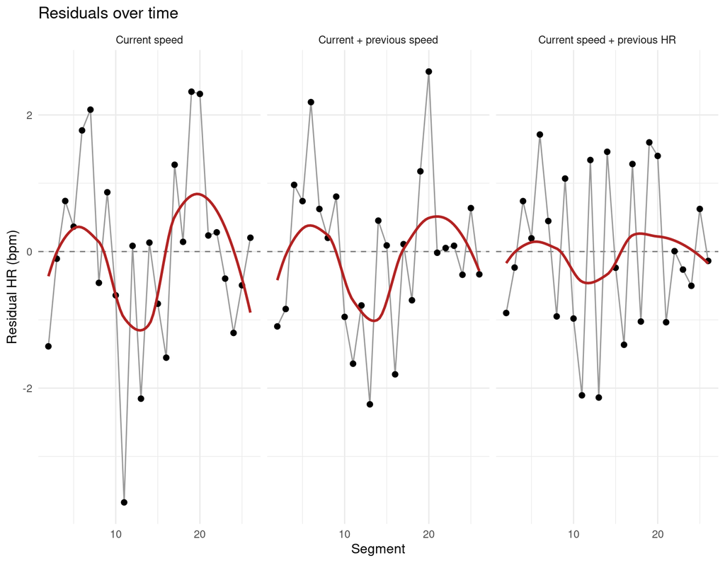

Figure 6: Residual diagnostics for the three baseline models (segments 2–26).

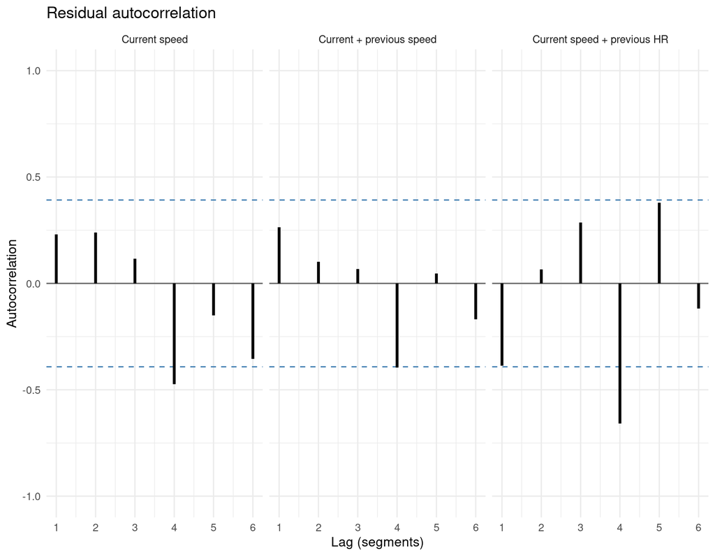

Figure 7: Residual diagnostics for the three baseline models (segments 2–26).

```r
diag_base <- plot_residual_diagnostics(baseline, dd, labels = model_labels)
diag_base$time
diag_base$acf
```

Both carryover terms improved on current speed alone. **Previous speed** has a positive coefficient: a faster preceding segment goes with a higher HR now, at the same current speed and time. **Previous HR** captures the combined carryover of earlier speed, cadence and anything else.

The two models answer slightly different questions. Neither is assumed to be the right one. All three are carried forward as a sensitivity analysis.

# 7 Cadence

## 7.1 Model specification

The same cadence term is added to each of the three baselines. Cadence is centred on its mean and expressed per 10 steps/min: [ g(c) = _1 z + _2 z^2, z = . ] Curvature $\gamma_2$ is left unconstrained, so a U-shape is not forced. If $\gamma_2 > 0$, HR is lowest at [ c^* = c_0 - 10,. ] Each linear model starts from its fitted baseline, and each quadratic model starts from its fitted linear model.

```r
cadence_reference <- mean(dd$cadence)
dd$cadence_10     <- (dd$cadence - cadence_reference) / 10
observed_range    <- range(dd$cadence)

carry_names <- names(carry_terms)

fits_linear <- setNames(lapply(carry_names, function(k) {
    fit_hr(k, "linear", c(coef(baseline[[k]]), beta_cadence = 0.1))
}), carry_names)

fits_quadratic <- setNames(lapply(carry_names, function(k) {
    fit_hr(k, "quadratic", c(coef(fits_linear[[k]]), beta_cadence2 = 0))
}), carry_names)
```

## 7.2 Model comparison

```r
all_fits <- c(
    setNames(baseline,       paste0(carry_names, " / no cadence")),
    setNames(fits_linear,    paste0(carry_names, " / linear")),
    setNames(fits_quadratic, paste0(carry_names, " / quadratic"))
)

compare_models(all_fits, dd) |> knitr::kable(digits = 3, row.names = FALSE)
```

| model | n | K | RMSE_bpm | residual_lag1 | AIC | AICc | converged | delta_AICc |
| --- | --- | --- | --- | --- | --- | --- | --- | --- |
| previous_speed / no cadence | 25 | 6 | 1.121 | 0.269 | 88.675 | 93.342 | TRUE | 0.000 |
| previous_hr / no cadence | 25 | 6 | 1.122 | -0.392 | 88.681 | 93.347 | TRUE | 0.006 |
| previous_hr / linear | 25 | 7 | 1.095 | -0.373 | 89.483 | 96.071 | TRUE | 2.729 |
| previous_speed / linear | 25 | 7 | 1.105 | 0.294 | 89.917 | 96.505 | TRUE | 3.163 |
| previous_speed / quadratic | 25 | 8 | 1.082 | 0.280 | 90.904 | 99.904 | TRUE | 6.562 |
| current_speed / no cadence | 25 | 5 | 1.372 | 0.236 | 96.749 | 99.907 | TRUE | 6.565 |
| previous_hr / quadratic | 25 | 8 | 1.084 | -0.433 | 90.974 | 99.974 | TRUE | 6.632 |
| current_speed / linear | 25 | 6 | 1.337 | 0.266 | 97.474 | 102.141 | TRUE | 8.799 |
| current_speed / quadratic | 25 | 7 | 1.333 | 0.237 | 99.321 | 105.910 | TRUE | 12.568 |

Look at the comparison within each carryover family as well as overall. Does the quadratic term clearly beat both the no-cadence and linear versions?

## 7.3 Estimated HR-minimising cadence

The uncertainty of $c^*$ comes from the delta method, using the covariance of $(\gamma_1, \gamma_2)$. Leave-one-out refits show how much the estimate moves when any single segment is dropped.

```r
cadence_minimum <- function(p) {
    if (p["beta_cadence2"] <= 0) return(NA_real_)
    unname(cadence_reference - 10 * p["beta_cadence"] / (2 * p["beta_cadence2"]))
}

minimum_se <- function(model) {
    p <- coef(model)
    if (p["beta_cadence2"] <= 0) return(NA_real_)
    g <- c(-5 / p["beta_cadence2"],
           5 * p["beta_cadence"] / p["beta_cadence2"]^2)
    V <- vcov(model)[c("beta_cadence", "beta_cadence2"),
                     c("beta_cadence", "beta_cadence2")]
    sqrt(as.numeric(t(g) %*% V %*% g))
}

loo_minima <- function(k) {
    vapply(seq_len(nrow(dd)), function(i) {
        fit <- tryCatch(
            fit_hr(k, "quadratic", coef(fits_quadratic[[k]]), data = dd[-i, ]),
            error = function(e) NULL
        )
        if (is.null(fit)) NA_real_ else cadence_minimum(coef(fit))
    }, numeric(1))
}

minima <- do.call(rbind, lapply(carry_names, function(k) {
    m   <- fits_quadratic[[k]]
    p   <- coef(m)
    est <- cadence_minimum(p)
    se  <- minimum_se(m)
    loo <- loo_minima(k)
    data.frame(
        model            = model_labels[[k]],
        curvature_per_10 = unname(p["beta_cadence2"]),
        curvature_lo     = confint.default(m, parm = "beta_cadence2")[1],
        curvature_hi     = confint.default(m, parm = "beta_cadence2")[2],
        minimum_spm      = est,
        wald_lo          = est - 1.96 * se,
        wald_hi          = est + 1.96 * se,
        within_range     = is.finite(est) && est >= observed_range[1] && est <= observed_range[2],
        loo_min          = suppressWarnings(min(loo, na.rm = TRUE)),
        loo_max          = suppressWarnings(max(loo, na.rm = TRUE)),
        loo_failed       = sum(is.na(loo))
    )
}))

minima |> knitr::kable(digits = 2, row.names = FALSE)
```

| model | curvature_per_10 | curvature_lo | curvature_hi | minimum_spm | wald_lo | wald_hi | within_range | loo_min | loo_max | loo_failed |
| --- | --- | --- | --- | --- | --- | --- | --- | --- | --- | --- |
| Current speed | 0.24 | -1.10 | 1.59 | 188.80 | 138.42 | 239.18 | TRUE | 175.25 | 197.41 | 2 |
| Current + previous speed | 0.54 | -0.60 | 1.68 | 195.04 | 186.71 | 203.36 | TRUE | 192.34 | 197.08 | 0 |
| Current speed + previous HR | 0.38 | -0.77 | 1.52 | 192.95 | 176.72 | 209.18 | TRUE | 184.92 | 196.76 | 1 |

`curvature_per_10` is the quadratic coefficient, in bpm per (10 steps/min)². Its interval shows whether the U-shape is supported at all. A minimum computed from an almost flat curve is not meaningful, however precise the number looks. The Wald interval for $c^*$ is a rough guide. A ratio of coefficients can have a strongly asymmetric sampling distribution.

## 7.4 Cadence curves with adjusted observations

For each model, the plotted points are [ _i = _i + g(c_i). ] This is the observed HR minus the model’s fitted time, speed and carryover contributions. Zero is the model’s non-cadence prediction at the reference cadence $c_0$. The ribbon is a pointwise 95% Wald band for $\hat g(c)$ relative to $c_0$, so it narrows to zero at $c_0$ by construction.

The three models adjust for different things, so each has its own set of points.

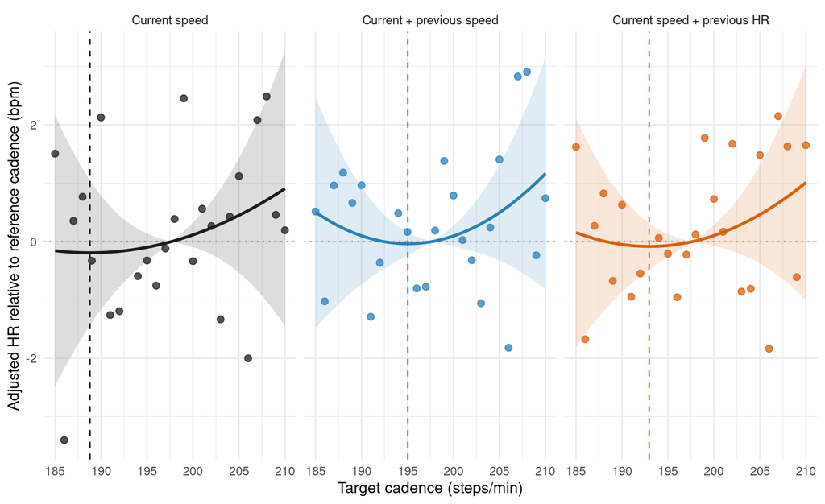

Figure 8: Fitted cadence contribution (line, 95% band) and model-adjusted segment HR (points) for each carryover specification. Dashed lines mark the estimated minima.

```r
cadence_grid <- seq(observed_range[1], observed_range[2], length.out = 300)
z_grid       <- (cadence_grid - cadence_reference) / 10

curve_df <- bind_rows(lapply(carry_names, function(k) {
    m <- fits_quadratic[[k]]
    p <- coef(m)
    V <- vcov(m)[c("beta_cadence", "beta_cadence2"), c("beta_cadence", "beta_cadence2")]
    X <- cbind(z_grid, z_grid^2)
    data.frame(
        model   = k,
        cadence = cadence_grid,
        fit     = as.numeric(X %*% p[c("beta_cadence", "beta_cadence2")]),
        se      = sqrt(rowSums((X %*% V) * X))
    )
}))

point_df <- bind_rows(lapply(carry_names, function(k) {
    m <- fits_quadratic[[k]]
    p <- coef(m)
    g <- p["beta_cadence"] * dd$cadence_10 + p["beta_cadence2"] * dd$cadence_10^2
    data.frame(
        model       = k,
        cadence     = dd$cadence,
        adjusted_hr = dd$y - as.numeric(predict(m, newdata = dd)) + g
    )
}))

minima_df <- data.frame(model = carry_names,
                        minimum = minima$minimum_spm) |>
    filter(is.finite(minimum),
           minimum >= observed_range[1], minimum <= observed_range[2])

curve_df$model  <- factor(curve_df$model,  levels = carry_names)
point_df$model  <- factor(point_df$model,  levels = carry_names)
minima_df$model <- factor(minima_df$model, levels = carry_names)

facet_labeller <- as_labeller(model_labels)

ggplot(curve_df, aes(cadence, fit, colour = model, fill = model)) +
    geom_hline(yintercept = 0, linetype = 3, colour = "grey60") +
    geom_ribbon(aes(ymin = fit - 1.96 * se, ymax = fit + 1.96 * se),
                alpha = 0.15, colour = NA) +
    geom_point(data = point_df, aes(y = adjusted_hr), size = 2.2, alpha = 0.75) +
    geom_line(linewidth = 1.1) +
    geom_vline(data = minima_df, aes(xintercept = minimum, colour = model),
               linetype = 2) +
    facet_wrap(~ model, nrow = 1, labeller = facet_labeller) +
    scale_colour_manual(values = model_colours, guide = "none") +
    scale_fill_manual(values = model_colours, guide = "none") +
    labs(x = params$cadence_label,
         y = "Adjusted HR relative to reference cadence (bpm)")
```

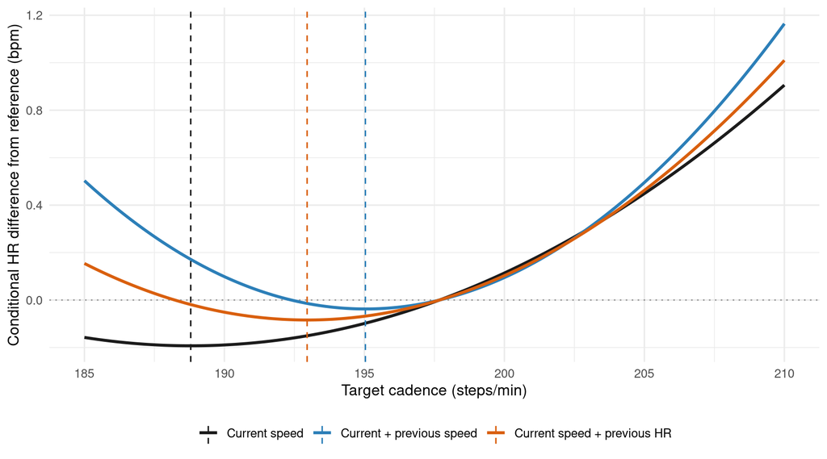

Figure 9: Fitted cadence curves from the three carryover specifications on a common scale.

```r
ggplot(curve_df, aes(cadence, fit, colour = model)) +
    geom_hline(yintercept = 0, linetype = 3, colour = "grey60") +
    geom_line(linewidth = 1.1) +
    geom_vline(data = minima_df, aes(xintercept = minimum, colour = model),
               linetype = 2) +
    scale_colour_manual(values = model_colours, labels = model_labels) +
    labs(x = params$cadence_label,
         y = "Conditional HR difference from reference (bpm)",
         colour = NULL) +
    theme(legend.position = "bottom")
```

## 7.5 Residual checks for the cadence models

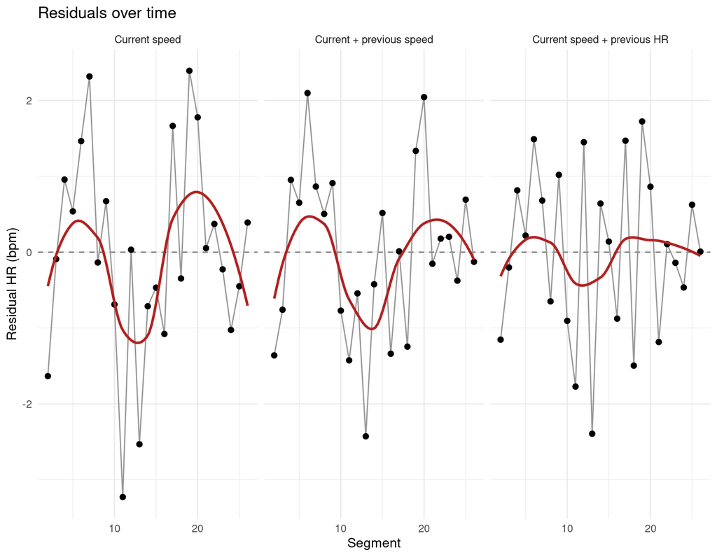

Figure 10: Residual diagnostics for the three quadratic-cadence models.

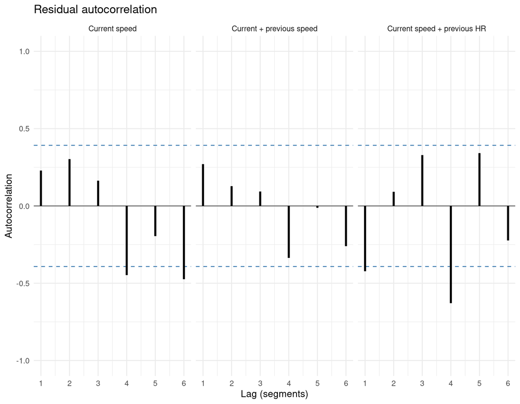

Figure 11: Residual diagnostics for the three quadratic-cadence models.

```r
diag_cad <- plot_residual_diagnostics(fits_quadratic, dd, labels = model_labels)
diag_cad$time
diag_cad$acf
```

```r
for (k in carry_names) {
    cat("\n\n**", model_labels[[k]], "**\n\n", sep = "")
    print(knitr::kable(summary(fits_quadratic[[k]])$coefficients, digits = 4))
}
```

**Current speed**

|  | Estimate | Std. Error | t value | Pr(>\|t\|) |
| --- | --- | --- | --- | --- |
| start_hr | 163.0133 | 1.5284 | 106.6593 | 0.0000 |
| final_hr | 173.2848 | 1.0392 | 166.7445 | 0.0000 |
| growth_rate | 0.1322 | 0.0544 | 2.4305 | 0.0252 |
| beta_current | 11.8275 | 3.7518 | 3.1525 | 0.0052 |
| beta_cadence | 0.4341 | 0.4250 | 1.0214 | 0.3199 |
| beta_cadence2 | 0.2443 | 0.6853 | 0.3565 | 0.7254 |

**Current + previous speed**

|  | Estimate | Std. Error | t value | Pr(>\|t\|) |
| --- | --- | --- | --- | --- |
| start_hr | 164.0034 | 1.2523 | 130.9619 | 0.0000 |
| final_hr | 173.1783 | 1.0426 | 166.1006 | 0.0000 |
| growth_rate | 0.1174 | 0.0486 | 2.4179 | 0.0264 |
| beta_current | 13.7720 | 3.2008 | 4.3027 | 0.0004 |
| beta_previous | 10.0203 | 3.2809 | 3.0541 | 0.0068 |
| beta_cadence | 0.2839 | 0.3576 | 0.7939 | 0.4376 |
| beta_cadence2 | 0.5367 | 0.5810 | 0.9237 | 0.3679 |

**Current speed + previous HR**

|  | Estimate | Std. Error | t value | Pr(>\|t\|) |
| --- | --- | --- | --- | --- |
| start_hr | 166.2468 | 3.0770 | 54.0297 | 0.0000 |
| final_hr | 174.4751 | 6.0373 | 28.8993 | 0.0000 |
| growth_rate | 0.0638 | 0.1112 | 0.5737 | 0.5733 |
| beta_current | 13.7300 | 3.2180 | 4.2667 | 0.0005 |
| phi | 0.4585 | 0.1476 | 3.1061 | 0.0061 |
| beta_cadence | 0.3559 | 0.3554 | 1.0015 | 0.3299 |
| beta_cadence2 | 0.3766 | 0.5847 | 0.6440 | 0.5277 |

# 8 Summary

Estimated HR-minimising cadence at about 3:55 min/km, by carryover specification:

- **Current speed:** 188.8 steps/min (approx. 95% CI 138.4 to 239.2)
- **Current + previous speed:** 195.0 steps/min (approx. 95% CI 186.7 to 203.4)
- **Current speed + previous HR:** 193.0 steps/min (approx. 95% CI 176.7 to 209.2)

How to read these results:

1. **Agreement across models.** If all three give an interior minimum in a similar place, the result does not depend much on how carryover is modelled. That is reassuring, but it is not proof.
2. **Effect size.** Use the curves to see how many bpm separate the minimum from the edges of the tested range. In one outdoor study of recreational runners, switching from preferred to optimal cadence predicted a median HR reduction of only about 0.5 bpm. A shallow curve can produce a well-defined but practically unimportant minimum.
3. **What “efficient” means here.** HR stands in for metabolic cost. It is affected by cardiac drift, temperature and hydration, which the time trend only partly captures. The cadence term in the previous-HR model is also conditional on the HR state carried in from the segment before. It is a short-run effect at the segment level, not the steady-state difference from holding one cadence for longer.
4. **Design limits.** This is one session of 25 usable one-minute segments, run on a track at prescribed (not measured) cadence, with 35-second windows that may not reach full HR equilibrium. A repeat session with a new random order, ideally on a treadmill or with longer segments, would be the most informative next step.